# Loan Data from Prosper

### LoanStatus VS

> [ StatedMonthlyIncome , EmploymentStatusDuration' , CurrentDelinquencies', DelinquenciesLast7Years' ]

[figure not shown]

```python
# Shape Variables that affect LoanStatus .
def relationship (z,n):
    col = sb.color_palette()[0]
    # the relationship between 'LoanStatus'VS'.
    plt.subplot(3, 2, n)
    sb.violinplot(data = df6,  x = z ,y = 'LoanStatus',color = col )
    plt.yticks(rotation = 30);
    plt.xlabel('Z'.title(), fontsize=10, loc="left" ,weight="bold");
    if n==1 or n==2:
        plt.title(f'Relationship LoanStatus VS '.title(), fontsize=10, loc="left" ,weight="bold");

plt.subplots(figsize=[14,10])

# the relationship between 'LoanStatus'VS'LoanOriginalAmount'.
relationship("LoanOriginalAmount",1);
# the relationship between 'LoanStatus'VS'BorrowerAPR'.
relationship("BorrowerAPR",2);
# the relationship between 'LoanStatus'VS'StatedMonthlyIncome'.
relationship("StatedMonthlyIncome",3);
# the relationship between 'LoanStat,us'VS'EmploymentStatusDuration'.
relationship("EmploymentStatusDuration",4);
# the relationship between 'LoanStat,us'VS'CurrentDelinquencies'.
relationship("CurrentDelinquencies",5);
# the relationship between 'LoanStatus'VS'DelinquenciesLast7Years'.
relationship("DelinquenciesLast7Years",6);
```

> the LoanOriginalAmount and StatedMonthlyIncome and EmploymentStatusDuration not effected on LoanStatus.

> the BorrowerAPR and CurrentDelinquencies and DelinquenciesLast7Years effected on LoanStatus.

### LoanStatus VS

> [ Term , EmploymentStatus]

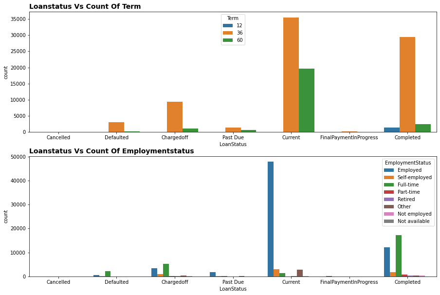

```python
def countrelation(z,n):
    plt.subplot(2, 1, n)
    sb.countplot(data = df6, x = "LoanStatus", hue = z );
    plt.title(f'LoanStatus vs count of {z}'.title(), fontsize=14, loc="left" ,weight="bold");

plt.subplots( figsize=[15,10])

# LoanStatus vs Term
countrelation("Term",1)
# LoanStatus vs EmploymentStatus
countrelation("EmploymentStatus",2)
```

### Talk about some of the relationships you observed in this part of the investigation. How did the feature(s) of interest vary with other features in the dataset?

> The borrower APR is positively correlated with (CurrentDelinquencies and DelinquenciesLast7Years) The borrower APR is negatively associated with (LoanOriginalAmount , StatedMonthlyIncome)

> the relationship of APR and (StatedMonthlyIncome or EmploymentStatusDuration) not effected on LoanStatus.

> the relationship of APR and (CurrentDelinquencies or DelinquenciesLast7Years) effected on LoanStatus(Completed and Current).

### Did you observe any interesting relationships between the other features (not the main feature(s) of interest)?

> employment status duration not have a negative impact on the annual interest rate of the loan. And loan duration not have a positive alwey impact on the annual interest rate of the loan.